# R Notebook

Exploratory Data Analysis (EDA) - Generate questions about your data. - Search for answers by visualising, transforming, and modelling your data. - Use what you learn to refine your questions and/or generate new questions.

```r
library(tidyverse)
```

You can loosely word these questions as: What type of variation occurs within my variables? What type of covariation occurs between my variables?

- A variable is a quantity, quality, or property that you can measure.
- A value is the state of a variable when you measure it. The value of a variable may change from measurement to measurement.
- An observation is a set of measurements made under similar conditions (you usually make all of the measurements in an observation at the same time and on the same object). An observation will contain several values, each associated with a different variable. I’ll sometimes refer to an observation as a data point.
- Tabular data is a set of values, each associated with a variable and an observation. Tabular data is tidy if each value is placed in its own “cell”, each variable in its own column, and each observation in its own row.

Variation is the tendency of the values of a variable to change from measurement to measurement. The best way to understand that pattern is to visualise the distribution of the variable’s values.

```r
diamonds
```

| carat | cut | color | clarity | depth | table | price | x | y | z |
| --- | --- | --- | --- | --- | --- | --- | --- | --- | --- |
| 0.23 | Ideal | E | SI2 | 61.5 | 55.0 | 326 | 3.95 | 3.98 | 2.43 |
| 0.21 | Premium | E | SI1 | 59.8 | 61.0 | 326 | 3.89 | 3.84 | 2.31 |
| 0.23 | Good | E | VS1 | 56.9 | 65.0 | 327 | 4.05 | 4.07 | 2.31 |
| 0.29 | Premium | I | VS2 | 62.4 | 58.0 | 334 | 4.20 | 4.23 | 2.63 |
| 0.31 | Good | J | SI2 | 63.3 | 58.0 | 335 | 4.34 | 4.35 | 2.75 |
| 0.24 | Very Good | J | VVS2 | 62.8 | 57.0 | 336 | 3.94 | 3.96 | 2.48 |
| 0.24 | Very Good | I | VVS1 | 62.3 | 57.0 | 336 | 3.95 | 3.98 | 2.47 |
| 0.26 | Very Good | H | SI1 | 61.9 | 55.0 | 337 | 4.07 | 4.11 | 2.53 |
| 0.22 | Fair | E | VS2 | 65.1 | 61.0 | 337 | 3.87 | 3.78 | 2.49 |
| 0.23 | Very Good | H | VS1 | 59.4 | 61.0 | 338 | 4.00 | 4.05 | 2.39 |

[output cut: 990 more lines]

To examine the distribution of a categorical variable, use a bar chart:

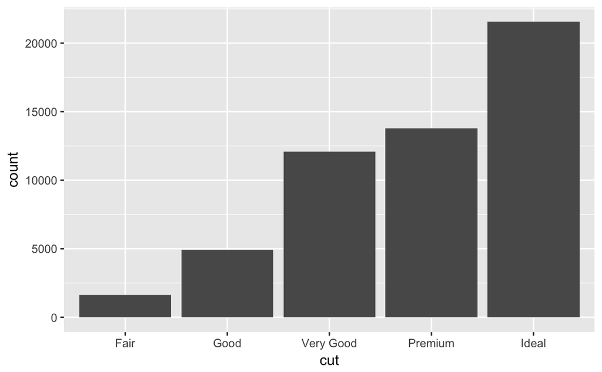

```r
ggplot(data = diamonds) +
  geom_bar(mapping = aes(x = cut))
```

```r
diamonds %>%
  count(cut)
```

| cut | n |
| --- | --- |
| Fair | 1610 |
| Good | 4906 |
| Very Good | 12082 |
| Premium | 13791 |
| Ideal | 21551 |

To examine the distribution of a continuous variable, use a histogram:

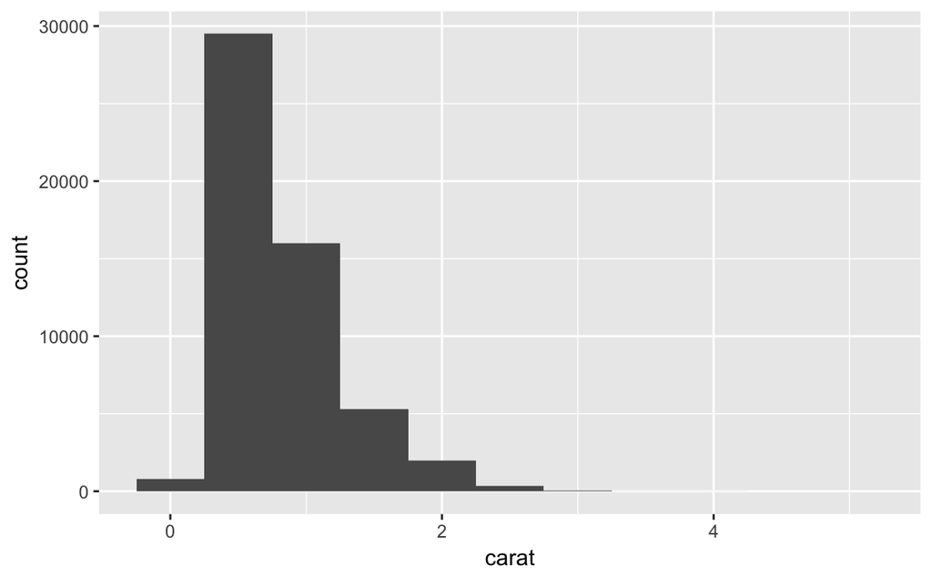

```r
ggplot(data = diamonds) +
  geom_histogram(mapping = aes(x = carat), binwidth = 0.5)
```

```r
diamonds %>%
  count(cut_width(carat, 0.5))
```

| cut_width(carat, 0.5) | n |
| --- | --- |
| [-0.25,0.25] | 785 |
| (0.25,0.75] | 29498 |
| (0.75,1.25] | 15977 |
| (1.25,1.75] | 5313 |
| (1.75,2.25] | 2002 |
| (2.25,2.75] | 322 |
| (2.75,3.25] | 32 |
| (3.25,3.75] | 5 |
| (3.75,4.25] | 4 |
| (4.25,4.75] | 1 |

[output cut: 1 more lines]

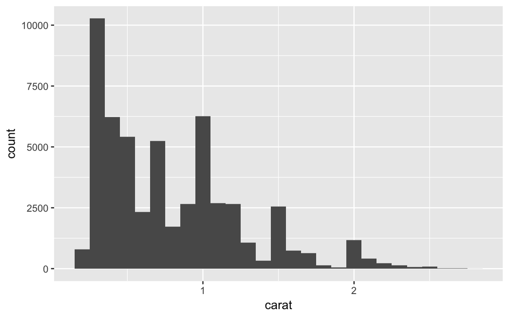

```r
smaller <- diamonds %>%
  filter(carat < 3)

ggplot(data = smaller, mapping = aes(x = carat)) +
  geom_histogram(binwidth = 0.1)
```

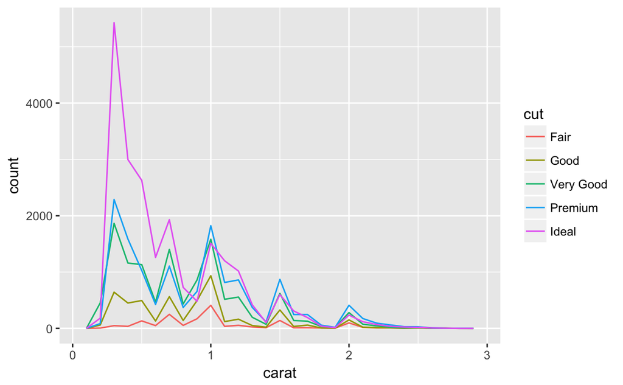

```r
ggplot(data = smaller, mapping = aes(x = carat, colour = cut)) +
  geom_freqpoly(binwidth = 0.1)
```

Some questions that could be asked: - Which values are the most common? Why? - Which values are rare? Why? Does that match your expectations? - Can you see any unusual patterns? What might explain them?

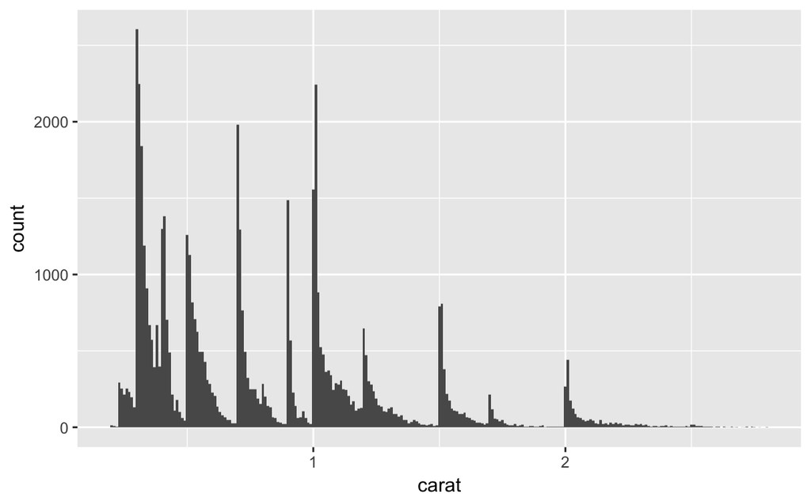

```r
ggplot(data = smaller, mapping = aes(x = carat)) +
  geom_histogram(binwidth = 0.01)
```

As an example, the histogram above suggests several interesting questions: - Why are there more diamonds at whole carats and common fractions of carats? - Why are there more diamonds slightly to the right of each peak than there are slightly to the left of each peak? - Why are there no diamonds bigger than 3 carats?

Clusters of similar values suggest that subgroups exist in your data. To understand the subgroups, ask: - How are the observations within each cluster similar to each other? - How are the observations in separate clusters different from each other? - How can you explain or describe the clusters? - Why might the appearance of clusters be misleading?

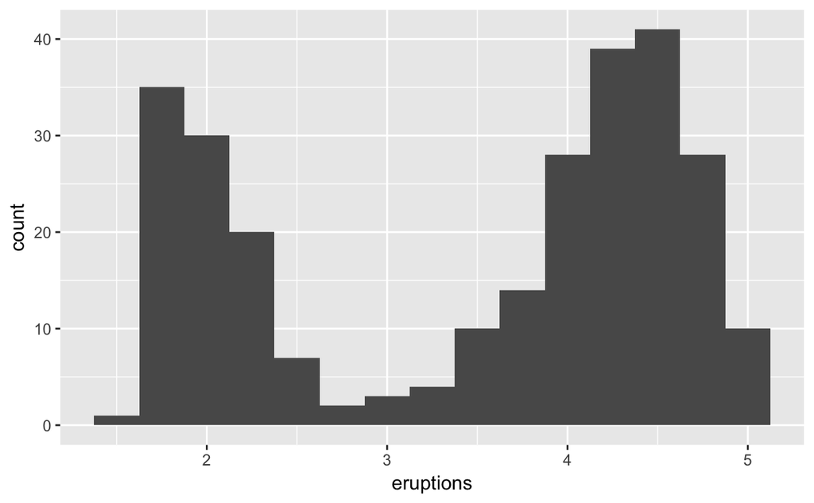

```r
ggplot(data = faithful, mapping = aes(x = eruptions)) +
  geom_histogram(binwidth = 0.25)
```

Discover outliers

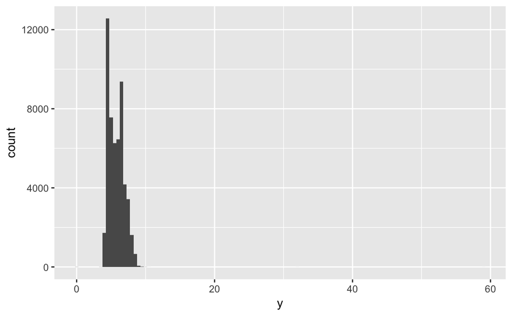

```r
ggplot(diamonds) +
  geom_histogram(mapping = aes(x = y), binwidth = 0.5)
```

Zoom in for outliers:

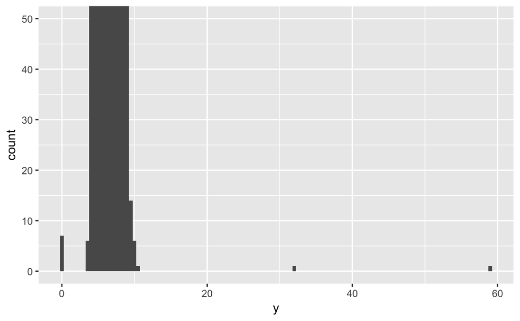

```r
ggplot(diamonds) +
  geom_histogram(mapping = aes(x = y), binwidth = 0.5) +
  coord_cartesian(ylim = c(0, 50))
```

```r
(unusual <- diamonds %>%
  filter(y < 3 | y > 20) %>%
  select(price, x, y, z) %>%
  arrange(y))
```

| price | x | y | z |
| --- | --- | --- | --- |
| 5139 | 0.00 | 0.0 | 0.00 |
| 6381 | 0.00 | 0.0 | 0.00 |
| 12800 | 0.00 | 0.0 | 0.00 |
| 15686 | 0.00 | 0.0 | 0.00 |
| 18034 | 0.00 | 0.0 | 0.00 |
| 2130 | 0.00 | 0.0 | 0.00 |
| 2130 | 0.00 | 0.0 | 0.00 |
| 2075 | 5.15 | 31.8 | 5.12 |
| 12210 | 8.09 | 58.9 | 8.06 |

Unreasonable data, probably error in entering them.

## Exercise P90

### 1

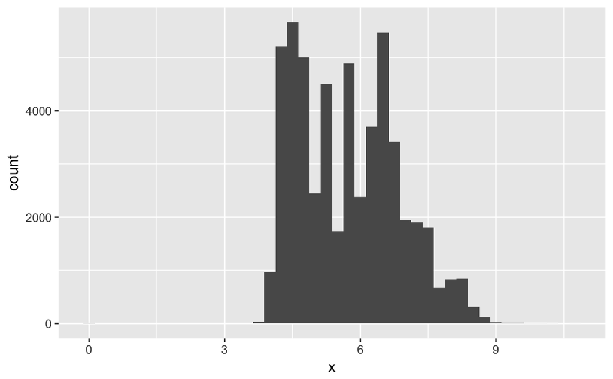

```r
ggplot(data = diamonds, mapping = aes(x = x)) +
  geom_histogram(binwidth = 0.25)
```

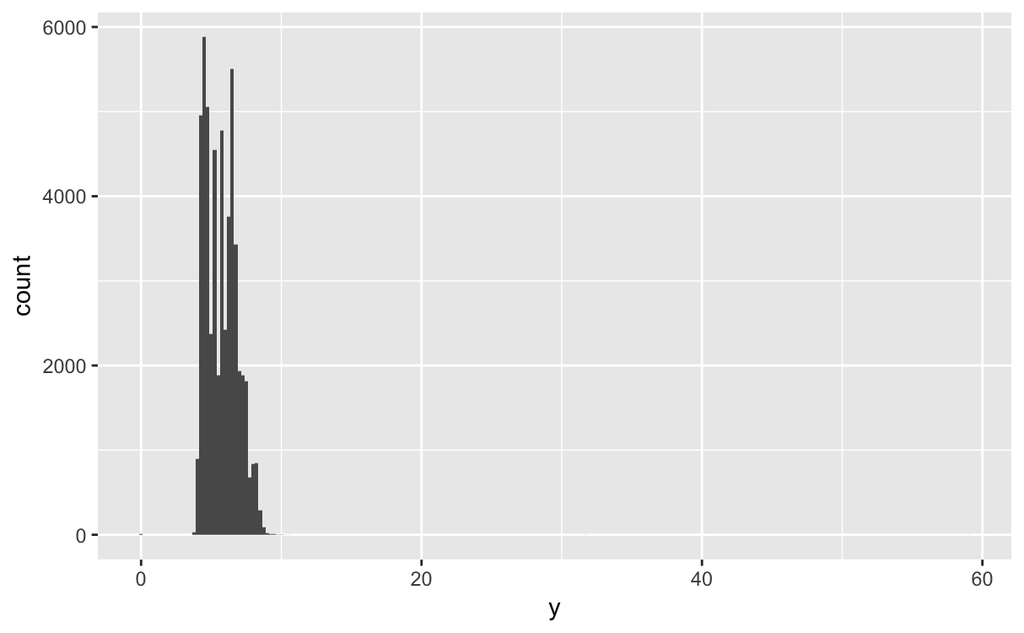

```r
ggplot(data = diamonds, mapping = aes(x = y)) +
  geom_histogram(binwidth = 0.25)
```

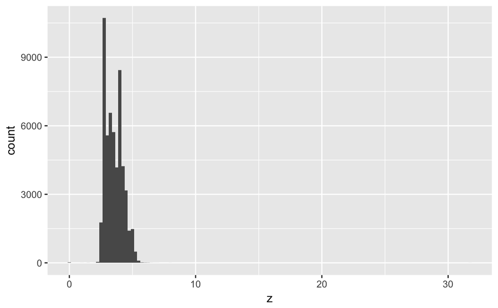

```r
ggplot(data = diamonds, mapping = aes(x = z)) +
  geom_histogram(binwidth = 0.25)
```

There are peaks, range: x

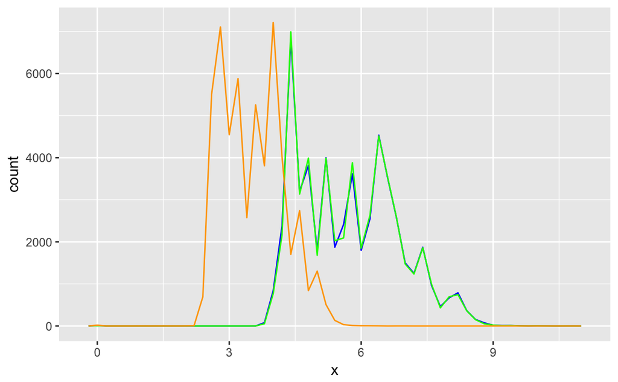

```r
xyz_diamonds <- filter(diamonds, x<20, y<20, z<20)
ggplot(data = xyz_diamonds) +
  geom_freqpoly(binwidth = 0.2, mapping = aes(x = x), color = "blue") +
  geom_freqpoly(binwidth = 0.2, mapping = aes(x = y), color = "green") +
  geom_freqpoly(binwidth = 0.2, mapping = aes(x = z), color = "orange")
```

### 2

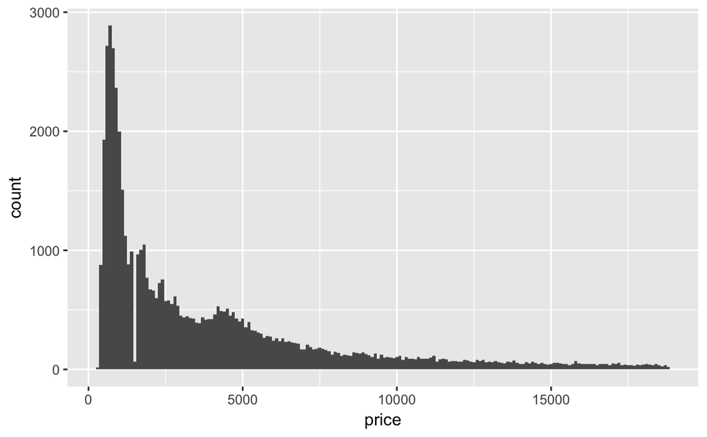

```r
ggplot(data = diamonds, mapping = aes(x = price)) +
  geom_histogram(binwidth = 100)
```

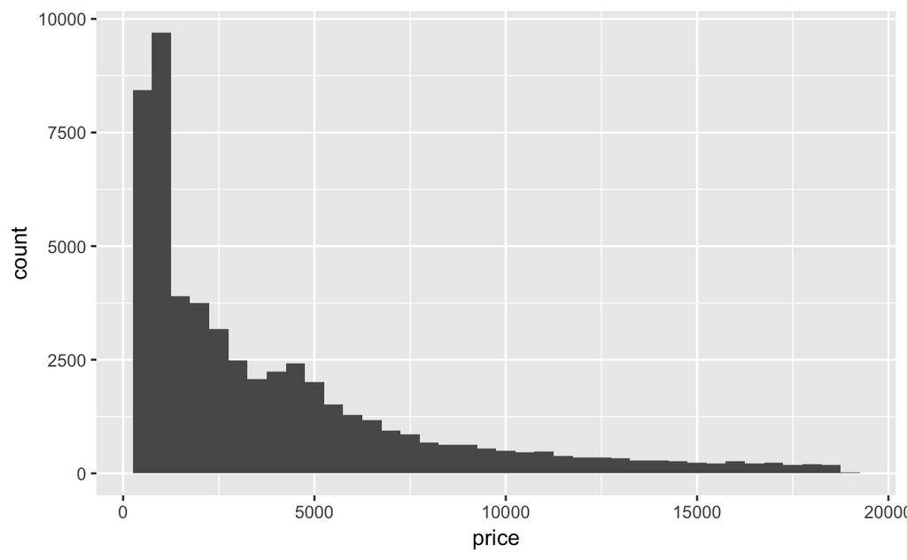

```r
ggplot(data = diamonds, mapping = aes(x = price)) +
  geom_histogram(binwidth = 500)
```

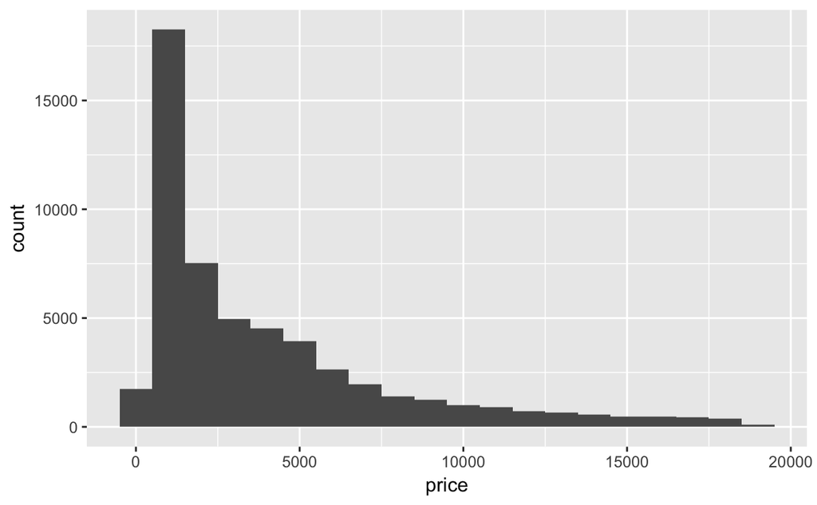

```r
ggplot(data = diamonds, mapping = aes(x = price)) +
  geom_histogram(binwidth = 1000)
```

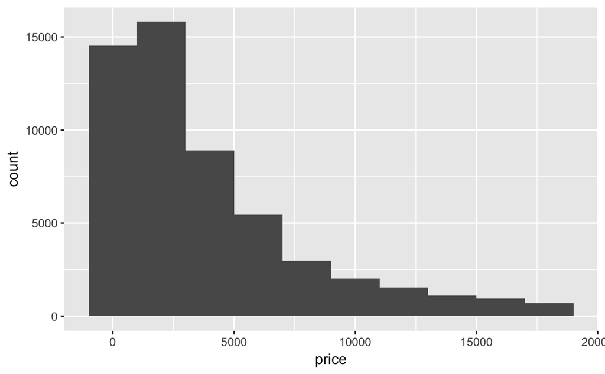

```r
ggplot(data = diamonds, mapping = aes(x = price)) +
  geom_histogram(binwidth = 2000)
```

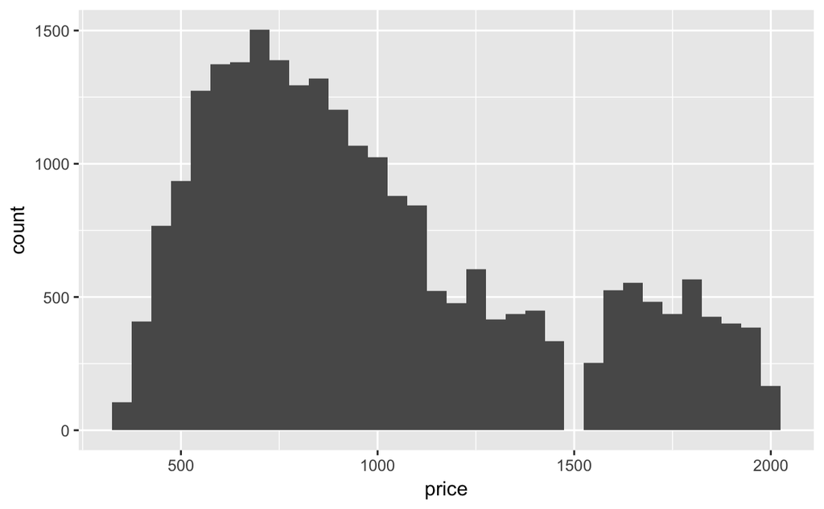

```r
diamonds_price <- filter(diamonds, price<2000)
ggplot(data = diamonds_price, mapping = aes(x = price)) +
  geom_histogram(binwidth = 50)
```

There is a gap at the price around 1500.

### 3

```r
(diamonds_carat <- filter(diamonds, carat == 0.99|carat == 1))
```

| carat | cut | color | clarity | depth | table | price | x | y | z |
| --- | --- | --- | --- | --- | --- | --- | --- | --- | --- |
| 1.00 | Premium | I | SI2 | 58.2 | 60.0 | 2795 | 6.61 | 6.55 | 3.83 |
| 1.00 | Premium | J | SI2 | 62.3 | 58.0 | 2801 | 6.45 | 6.34 | 3.98 |
| 1.00 | Fair | G | I1 | 66.4 | 59.0 | 2808 | 6.16 | 6.09 | 4.07 |
| 1.00 | Fair | J | VS2 | 65.7 | 59.0 | 2811 | 6.14 | 6.07 | 4.01 |
| 0.99 | Fair | I | SI2 | 68.1 | 56.0 | 2811 | 6.21 | 6.06 | 4.18 |
| 0.99 | Fair | J | SI1 | 55.0 | 61.0 | 2812 | 6.72 | 6.67 | 3.68 |
| 1.00 | Premium | H | I1 | 61.3 | 60.0 | 2818 | 6.43 | 6.39 | 3.93 |
| 1.00 | Fair | H | SI2 | 65.3 | 62.0 | 2818 | 6.34 | 6.12 | 4.08 |
| 1.00 | Premium | F | I1 | 58.9 | 60.0 | 2841 | 6.60 | 6.55 | 3.87 |
| 1.00 | Fair | G | SI2 | 67.8 | 61.0 | 2856 | 5.96 | 5.90 | 4.02 |

[output cut: 990 more lines]

```r
diamonds_carat %>%
  count(cut_width(carat, 0.01))
```

| cut_width(carat, 0.01) | n |
| --- | --- |
| [0.985,0.995] | 23 |
| (0.995,1] | 1558 |

People tend to make diamonds of 1 carat…

### 4

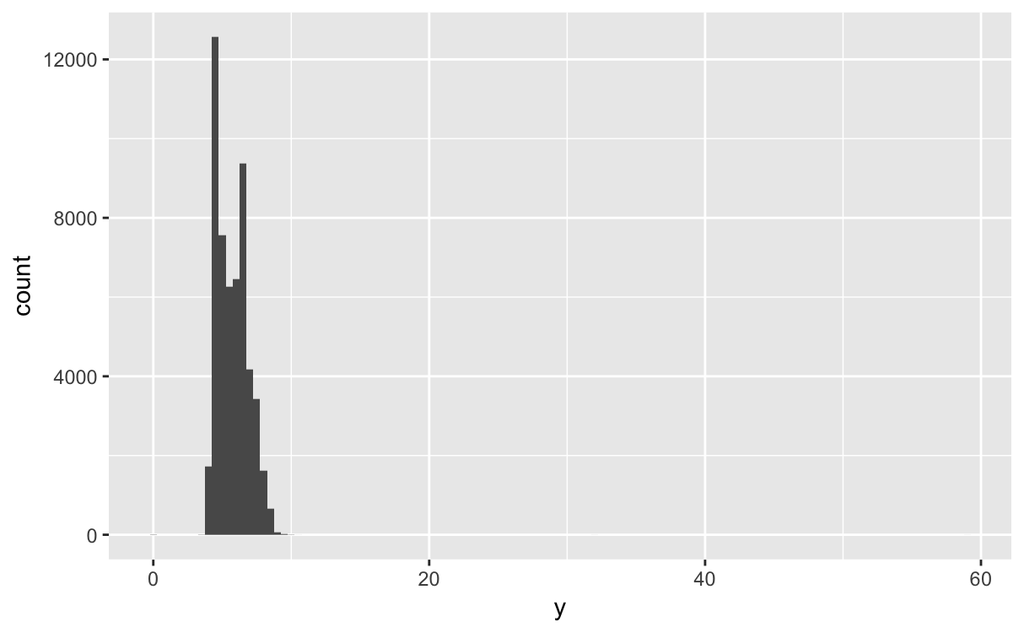

```r
ggplot(diamonds) +
  geom_histogram(mapping = aes(x = y), binwidth = 0.5)
```

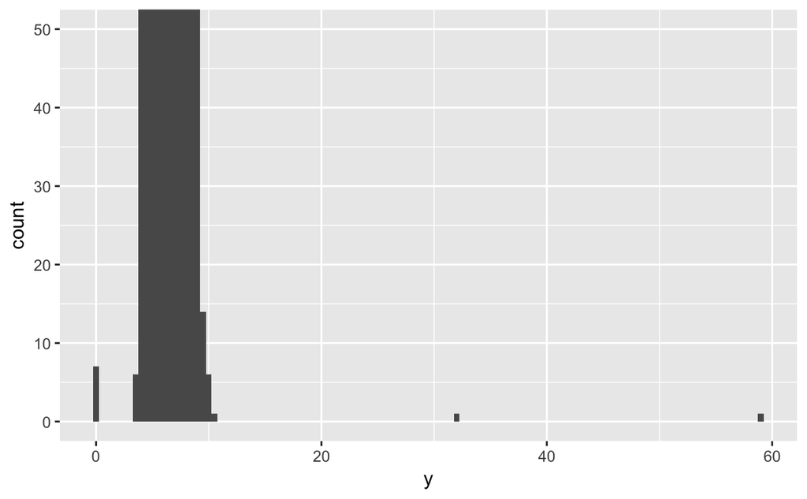

```r
ggplot(diamonds) +
  geom_histogram(mapping = aes(x = y), binwidth = 0.5) +
  coord_cartesian(ylim = c(0, 50))
```

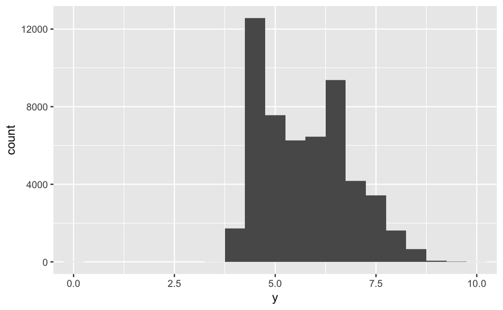

```r
ggplot(diamonds) +
  geom_histogram(mapping = aes(x = y), binwidth = 0.5) +
  coord_cartesian(xlim = c(0, 10))
```

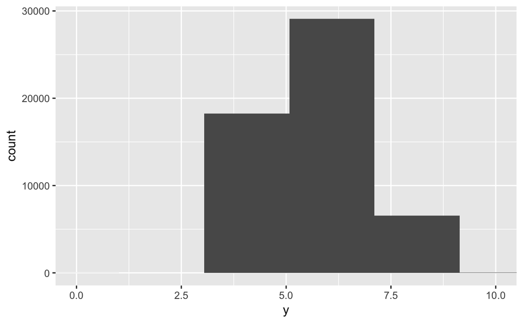

```r
ggplot(diamonds) +
  geom_histogram(mapping = aes(x = y)) +
  coord_cartesian(xlim = c(0, 10))
```

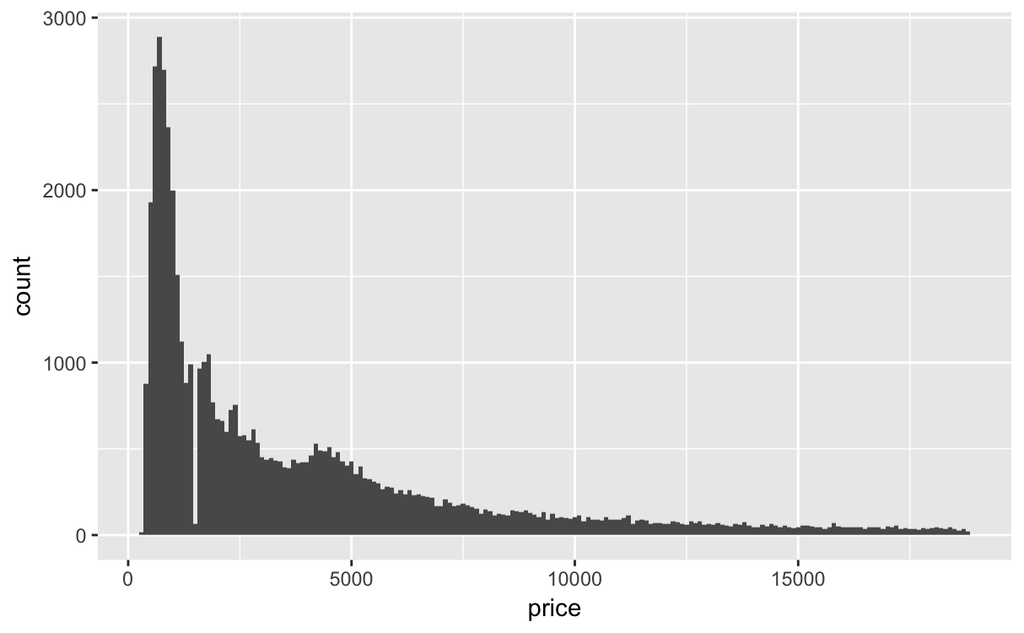

```r
ggplot(data = diamonds, mapping = aes(x = price)) +
  geom_histogram(binwidth = 100)
```

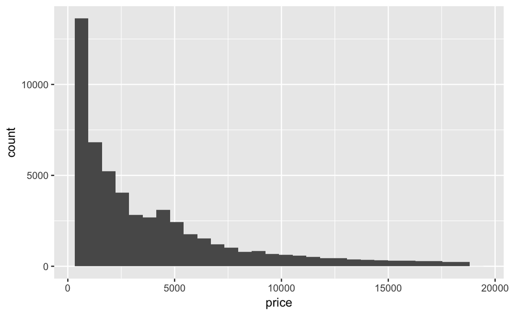

```r
ggplot(data = diamonds, mapping = aes(x = price))+
  geom_histogram()
```

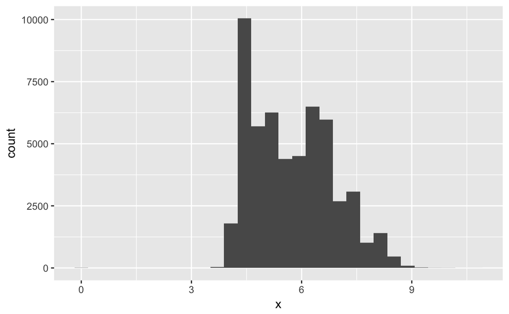

```r
ggplot(data = diamonds, mapping = aes(x = x))+
  geom_histogram()
```

R automatically picks a value so that there are 30 bins?

For unusual values

```r
diamonds2 <- diamonds %>%
  mutate(y = ifelse(y < 3 | y > 20, NA, y))
diamonds2
```

| carat | cut | color | clarity | depth | table | price | x | y | z |
| --- | --- | --- | --- | --- | --- | --- | --- | --- | --- |
| 0.23 | Ideal | E | SI2 | 61.5 | 55.0 | 326 | 3.95 | 3.98 | 2.43 |
| 0.21 | Premium | E | SI1 | 59.8 | 61.0 | 326 | 3.89 | 3.84 | 2.31 |
| 0.23 | Good | E | VS1 | 56.9 | 65.0 | 327 | 4.05 | 4.07 | 2.31 |
| 0.29 | Premium | I | VS2 | 62.4 | 58.0 | 334 | 4.20 | 4.23 | 2.63 |
| 0.31 | Good | J | SI2 | 63.3 | 58.0 | 335 | 4.34 | 4.35 | 2.75 |
| 0.24 | Very Good | J | VVS2 | 62.8 | 57.0 | 336 | 3.94 | 3.96 | 2.48 |
| 0.24 | Very Good | I | VVS1 | 62.3 | 57.0 | 336 | 3.95 | 3.98 | 2.47 |
| 0.26 | Very Good | H | SI1 | 61.9 | 55.0 | 337 | 4.07 | 4.11 | 2.53 |
| 0.22 | Fair | E | VS2 | 65.1 | 61.0 | 337 | 3.87 | 3.78 | 2.49 |
| 0.23 | Very Good | H | VS1 | 59.4 | 61.0 | 338 | 4.00 | 4.05 | 2.39 |

[output cut: 990 more lines]

ifelse() has three arguments. The first argument test should be a logical vector. The result will contain the value of the second argument, yes, when test is TRUE, and the value of the third argument, no, when it is false.

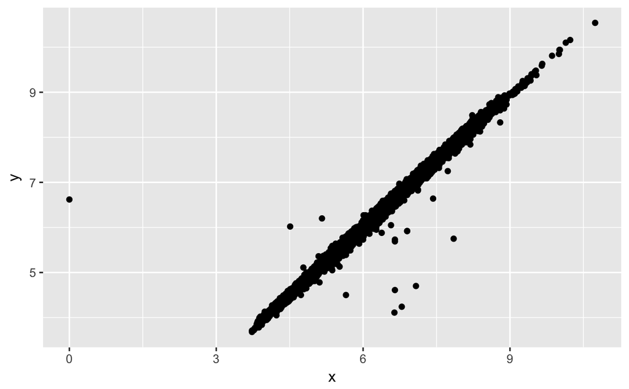

```r
ggplot(data = diamonds2, mapping = aes(x = x, y = y)) +
  geom_point()
```

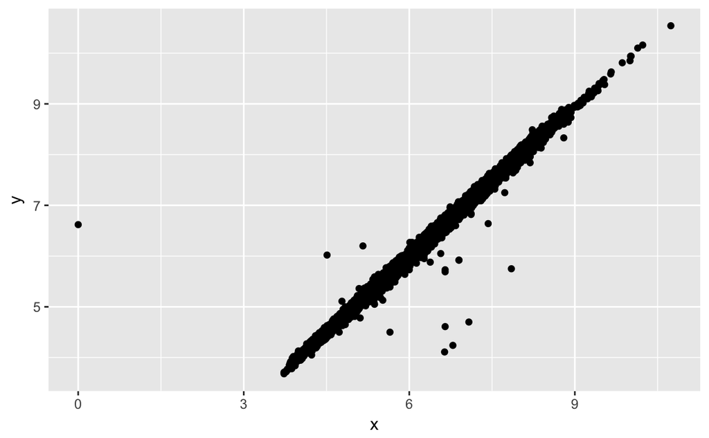

```r
ggplot(data = diamonds2, mapping = aes(x = x, y = y)) +
  geom_point(na.rm = TRUE)
```

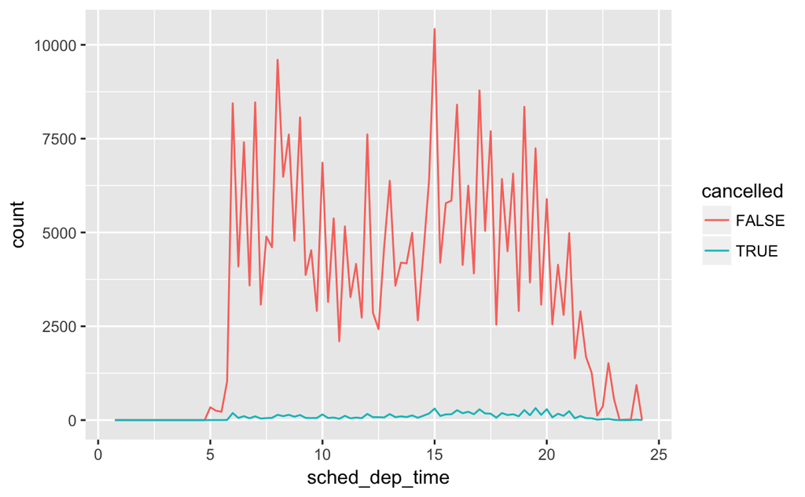

```r
nycflights13::flights %>%
  mutate(
    cancelled = is.na(dep_time),
    sched_hour = sched_dep_time %/% 100,
    sched_min = sched_dep_time %% 100,
    sched_dep_time = sched_hour + sched_min / 60
  ) %>%
  ggplot(mapping = aes(sched_dep_time)) +
    geom_freqpoly(mapping = aes(colour = cancelled), binwidth = 1/4)
```

## Exercise P93

### 1

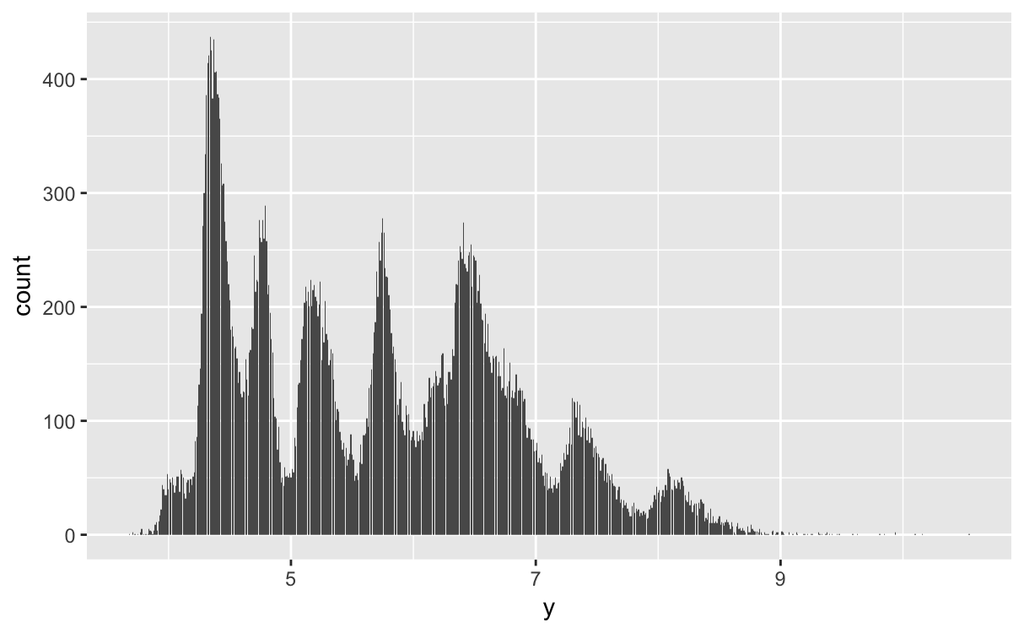

```r
ggplot(data = diamonds2, mapping = aes(x = y)) +
  geom_bar()
```

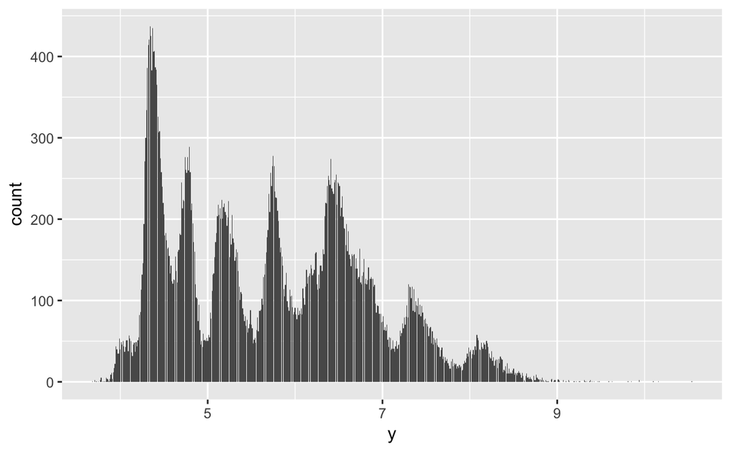

```r
ggplot(data = diamonds2, mapping = aes(x = y)) +
  geom_bar(na.rm = TRUE)
```

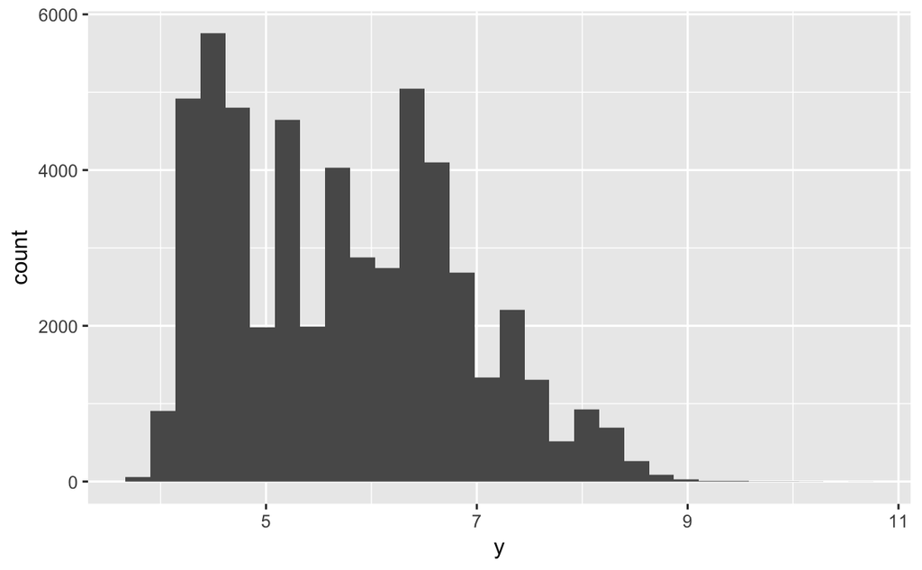

```r
ggplot(data = diamonds2, mapping = aes(x = y)) +
  geom_histogram()
```

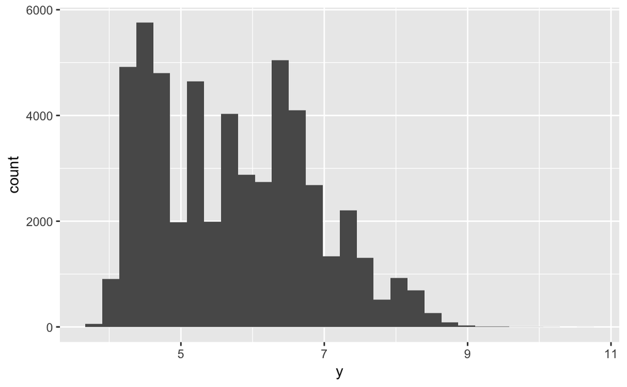

```r
ggplot(data = diamonds2, mapping = aes(x = y)) +
  geom_histogram(na.rm = TRUE)
```